# BSS Competition

Anubhav Shankar

2023-08-15

```r
bss <- read.csv("2023 INFORMS BSS Data Challenge Dataset.csv") # Ingest the data set

# Visualize the metadata
str(bss)
```

```
## 'data.frame':    122801 obs. of  20 variables:
##  $ sku                    : chr  "Envelopes SKU 4" "Envelopes SKU 4" "Envelopes SKU 4" "Envelopes SKU 4" ...
##  $ salesdate              : chr  "2022-01-01" "2022-01-02" "2022-01-03" "2022-01-04" ...
##  $ price                  : num  29.5 30 29.7 29.8 29.8 ...
##  $ unitsordered           : int  19 13 84 78 83 61 66 18 20 70 ...
##  $ sales                  : num  560 390 2494 2324 2473 ...
##  $ cogs                   : num  236 161 1042 968 1030 ...
##  $ fba                    : num  156 107 690 641 682 501 543 148 164 575 ...
##  $ reffee                 : num  84 58 374 349 371 273 290 81 90 314 ...
##  $ adspend                : num  0 0 0 0 0 0 0 0 0 0 ...
##  $ profit                 : num  84 64 388 366 390 292 281 88 98 334 ...
##  $ comp_1_price           : num  28.5 28.5 28.5 28.5 28.5 ...
##  $ comp_2_price           : num  28 28 28 28 28 ...
##  $ comp_3_price           : num  31 31 31 31 31 ...
##  $ comp_4_price           : num  NA NA NA NA NA NA NA NA NA NA ...
##  $ comp_5_price           : num  NA NA NA NA NA NA NA NA NA NA ...
##  $ comp_data_min_price    : num  28 28 28 28 28 ...
##  $ comp_data_max_price    : num  31 31 31 31 31 ...
##  $ managed_fba_stock_level: int  NA NA NA NA NA NA NA NA NA NA ...
##  $ min_price              : num  28 28 28 28 28 ...
##  $ max_price              : num  35 35 35 35 35 ...
```

```r
glimpse(bss)
```

```
## Rows: 122,801
## Columns: 20
## $ sku                     <chr> "Envelopes SKU 4", "Envelopes SKU 4", "Envelop…
## $ salesdate               <chr> "2022-01-01", "2022-01-02", "2022-01-03", "202…
## $ price                   <dbl> 29.49, 29.99, 29.69, 29.79, 29.79, 29.89, 29.2…
## $ unitsordered            <int> 19, 13, 84, 78, 83, 61, 66, 18, 20, 70, 102, 9…
## $ sales                   <dbl> 560, 390, 2494, 2324, 2473, 1823, 1933, 540, 6…
## $ cogs                    <dbl> 236, 161, 1042, 968, 1030, 757, 819, 223, 248,…
## $ fba                     <dbl> 156, 107, 690, 641, 682, 501, 543, 148, 164, 5…
## $ reffee                  <dbl> 84, 58, 374, 349, 371, 273, 290, 81, 90, 314, …
## $ adspend                 <dbl> 0, 0, 0, 0, 0, 0, 0, 0, 0, 0, 0, 0, 0, 0, 0, 0…
## $ profit                  <dbl> 84, 64, 388, 366, 390, 292, 281, 88, 98, 334, …
## $ comp_1_price            <dbl> 28.49, 28.49, 28.49, 28.49, 28.49, 28.49, 28.4…
## $ comp_2_price            <dbl> 27.97, 27.97, 27.97, 27.97, 27.97, 27.97, 27.9…
## $ comp_3_price            <dbl> 30.99, 30.99, 30.99, 30.99, 30.99, 30.99, 30.9…
## $ comp_4_price            <dbl> NA, NA, NA, NA, NA, NA, NA, NA, NA, NA, NA, NA…
## $ comp_5_price            <dbl> NA, NA, NA, NA, NA, NA, NA, NA, NA, NA, NA, NA…
## $ comp_data_min_price     <dbl> 27.97, 27.97, 27.97, 27.97, 27.97, 27.97, 27.9…
## $ comp_data_max_price     <dbl> 30.99, 30.99, 30.99, 30.99, 30.99, 30.99, 30.9…
## $ managed_fba_stock_level <int> NA, NA, NA, NA, NA, NA, NA, NA, NA, NA, NA, NA…
## $ min_price               <dbl> 27.99, 27.99, 27.99, 27.99, 27.99, 27.99, 27.9…
## $ max_price               <dbl> 34.99, 34.99, 34.99, 34.99, 34.99, 34.99, 34.9…
```

```r
head(bss) # Get a pivot of the first few rows
```

```
##               sku  salesdate price unitsordered sales cogs fba reffee adspend
## 1 Envelopes SKU 4 2022-01-01 29.49           19   560  236 156     84       0
## 2 Envelopes SKU 4 2022-01-02 29.99           13   390  161 107     58       0
## 3 Envelopes SKU 4 2022-01-03 29.69           84  2494 1042 690    374       0
## 4 Envelopes SKU 4 2022-01-04 29.79           78  2324  968 641    349       0
## 5 Envelopes SKU 4 2022-01-05 29.79           83  2473 1030 682    371       0
## 6 Envelopes SKU 4 2022-01-06 29.89           61  1823  757 501    273       0
##   profit comp_1_price comp_2_price comp_3_price comp_4_price comp_5_price
## 1     84        28.49        27.97        30.99           NA           NA
## 2     64        28.49        27.97        30.99           NA           NA
## 3    388        28.49        27.97        30.99           NA           NA
## 4    366        28.49        27.97        30.99           NA           NA
## 5    390        28.49        27.97        30.99           NA           NA
## 6    292        28.49        27.97        30.99           NA           NA
##   comp_data_min_price comp_data_max_price managed_fba_stock_level min_price
## 1               27.97               30.99                      NA     27.99
## 2               27.97               30.99                      NA     27.99
## 3               27.97               30.99                      NA     27.99
## 4               27.97               30.99                      NA     27.99
## 5               27.97               30.99                      NA     27.99
## 6               27.97               30.99                      NA     27.99
##   max_price
## 1     34.99
## 2     34.99
## 3     34.99
## 4     34.99
## 5     34.99
## 6     34.99
```

```r
summary(bss) # Get a basic data summary
```

```
##      sku             salesdate             price         unitsordered
##  Length:122801      Length:122801      Min.   :  0.00   Min.   :  0.00
##  Class :character   Class :character   1st Qu.: 15.79   1st Qu.:  2.00
##  Mode  :character   Mode  :character   Median : 24.49   Median :  7.00
##                                        Mean   : 22.12   Mean   : 18.83
##                                        3rd Qu.: 28.39   3rd Qu.: 23.00
##                                        Max.   :111.49   Max.   :833.00
##
##      sales              cogs             fba             reffee
##  Min.   :    0.0   Min.   :   0.0   Min.   :   0.0   Min.   :   0.00
##  1st Qu.:   42.0   1st Qu.:  14.0   1st Qu.:  13.0   1st Qu.:   6.00
##  Median :  178.0   Median :  60.0   Median :  53.0   Median :  27.00
##  Mean   :  476.8   Mean   : 157.6   Mean   : 137.2   Mean   :  71.52
##  3rd Qu.:  566.0   3rd Qu.: 182.0   3rd Qu.: 164.0   3rd Qu.:  85.00
##  Max.   :20900.0   Max.   :9654.0   Max.   :6847.0   Max.   :3135.00
##
##     adspend            profit          comp_1_price     comp_2_price
##  Min.   :   0.00   Min.   :-4379.00   Min.   :  4.84   Min.   :  4.95
##  1st Qu.:   0.00   1st Qu.:    0.00   1st Qu.: 19.79   1st Qu.: 19.48
##  Median :   7.00   Median :   17.00   Median : 26.28   Median : 25.92
##  Mean   :  29.42   Mean   :   81.14   Mean   : 28.17   Mean   : 27.57
##  3rd Qu.:  29.00   3rd Qu.:   84.00   3rd Qu.: 34.80   3rd Qu.: 32.49
##  Max.   :1628.00   Max.   : 6753.00   Max.   :106.97   Max.   :119.99
##                                       NA's   :44069    NA's   :74336
##   comp_3_price     comp_4_price     comp_5_price    comp_data_min_price
##  Min.   : 8.95    Min.   : 9.95    Min.   : 9.12    Min.   :  4.84
##  1st Qu.:15.97    1st Qu.:14.99    1st Qu.:12.98    1st Qu.: 18.29
##  Median :23.69    Median :21.97    Median :29.99    Median : 24.75
##  Mean   :27.48    Mean   :27.06    Mean   :27.16    Mean   : 26.24
##  3rd Qu.:32.64    3rd Qu.:30.15    3rd Qu.:36.89    3rd Qu.: 30.48
##  Max.   :81.46    Max.   :79.99    Max.   :49.83    Max.   :119.99
##  NA's   :102042   NA's   :115540   NA's   :121025   NA's   :37543
##  comp_data_max_price managed_fba_stock_level   min_price       max_price
##  Min.   :  5.58      Min.   :    0           Min.   : 6.99   Min.   :  4.99
##  1st Qu.: 21.77      1st Qu.:  284           1st Qu.:16.99   1st Qu.: 23.99
##  Median : 29.15      Median :  674           Median :21.99   Median : 32.99
##  Mean   : 31.43      Mean   : 1136           Mean   :23.10   Mean   : 33.26
##  3rd Qu.: 38.99      3rd Qu.: 1447           3rd Qu.:25.99   3rd Qu.: 36.99
##  Max.   :119.99      Max.   :20796           Max.   :91.99   Max.   :135.99
##  NA's   :37543       NA's   :24202
```

Let’s generate a pivot of NA values present in each column

```r
is_na_count <- bss %>% summarize_all(funs(sum(is.na(.)))) # Check the NA's in each field
print(is_na_count)
```

```
##   sku salesdate price unitsordered sales cogs fba reffee adspend profit
## 1   0         0     0            0     0    0   0      0       0      0
##   comp_1_price comp_2_price comp_3_price comp_4_price comp_5_price
## 1        44069        74336       102042       115540       121025
##   comp_data_min_price comp_data_max_price managed_fba_stock_level min_price
## 1               37543               37543                   24202         0
##   max_price
## 1         0
```

Let’s attempt to ascertain the nature of the missing values

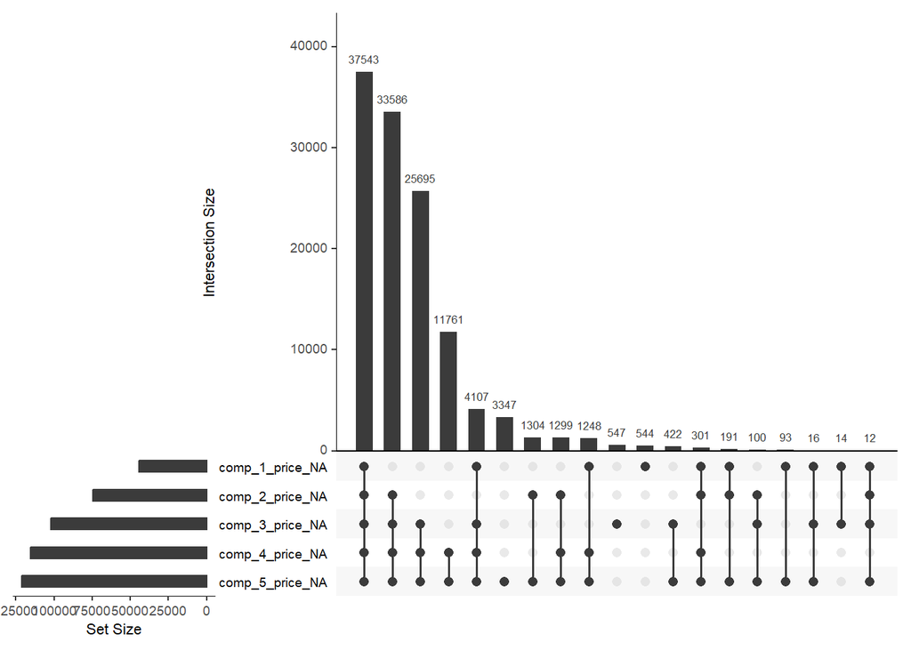

```r
gg_miss_upset(bss) # Upset plot
```

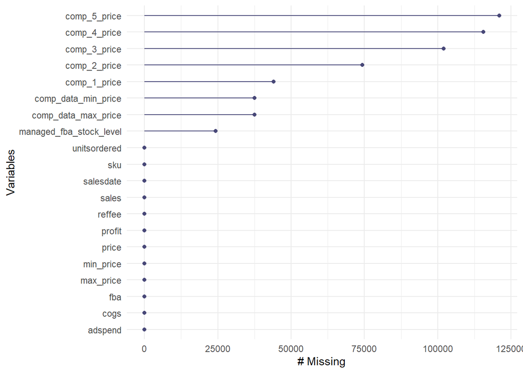

```r
gg_miss_var(bss)
```

We see that all the ‘comp_x_price’ columns have a lot of missing values. Ascertaining the nature of missing values will help in determining a suitable imputation method.  
Let’s create some copies of the original dataset for further exploration & experimentation.

```r
# bss_bkp <- bss
bss_refresh <- bss # will have simple median imputation
bss_train <- bss # will have interpolated imputation
```

```r
blank_count <- bss_refresh %>% summarize_all(funs(sum(is.na(.)))) # Check the NA's in each field
print(blank_count) # Just an added check, the counts here should match with the counts of the 'is_na_count' object
```

```
##   sku salesdate price unitsordered sales cogs fba reffee adspend profit
## 1   0         0     0            0     0    0   0      0       0      0
##   comp_1_price comp_2_price comp_3_price comp_4_price comp_5_price
## 1        44069        74336       102042       115540       121025
##   comp_data_min_price comp_data_max_price managed_fba_stock_level min_price
## 1               37543               37543                   24202         0
##   max_price
## 1         0
```

```r
bss_refresh$salesdate <- as.Date(bss_refresh$salesdate,"%Y-%m-%d") # Coerce the 'salesdate' into Date type

glimpse(bss_refresh)
```

```
## Rows: 122,801
## Columns: 20
## $ sku                     <chr> "Envelopes SKU 4", "Envelopes SKU 4", "Envelop…
## $ salesdate               <date> 2022-01-01, 2022-01-02, 2022-01-03, 2022-01-0…
## $ price                   <dbl> 29.49, 29.99, 29.69, 29.79, 29.79, 29.89, 29.2…
## $ unitsordered            <int> 19, 13, 84, 78, 83, 61, 66, 18, 20, 70, 102, 9…
## $ sales                   <dbl> 560, 390, 2494, 2324, 2473, 1823, 1933, 540, 6…
## $ cogs                    <dbl> 236, 161, 1042, 968, 1030, 757, 819, 223, 248,…
## $ fba                     <dbl> 156, 107, 690, 641, 682, 501, 543, 148, 164, 5…
## $ reffee                  <dbl> 84, 58, 374, 349, 371, 273, 290, 81, 90, 314, …
## $ adspend                 <dbl> 0, 0, 0, 0, 0, 0, 0, 0, 0, 0, 0, 0, 0, 0, 0, 0…
## $ profit                  <dbl> 84, 64, 388, 366, 390, 292, 281, 88, 98, 334, …
## $ comp_1_price            <dbl> 28.49, 28.49, 28.49, 28.49, 28.49, 28.49, 28.4…
## $ comp_2_price            <dbl> 27.97, 27.97, 27.97, 27.97, 27.97, 27.97, 27.9…
## $ comp_3_price            <dbl> 30.99, 30.99, 30.99, 30.99, 30.99, 30.99, 30.9…
## $ comp_4_price            <dbl> NA, NA, NA, NA, NA, NA, NA, NA, NA, NA, NA, NA…
## $ comp_5_price            <dbl> NA, NA, NA, NA, NA, NA, NA, NA, NA, NA, NA, NA…
## $ comp_data_min_price     <dbl> 27.97, 27.97, 27.97, 27.97, 27.97, 27.97, 27.9…
## $ comp_data_max_price     <dbl> 30.99, 30.99, 30.99, 30.99, 30.99, 30.99, 30.9…
## $ managed_fba_stock_level <int> NA, NA, NA, NA, NA, NA, NA, NA, NA, NA, NA, NA…
## $ min_price               <dbl> 27.99, 27.99, 27.99, 27.99, 27.99, 27.99, 27.9…
## $ max_price               <dbl> 34.99, 34.99, 34.99, 34.99, 34.99, 34.99, 34.9…
```

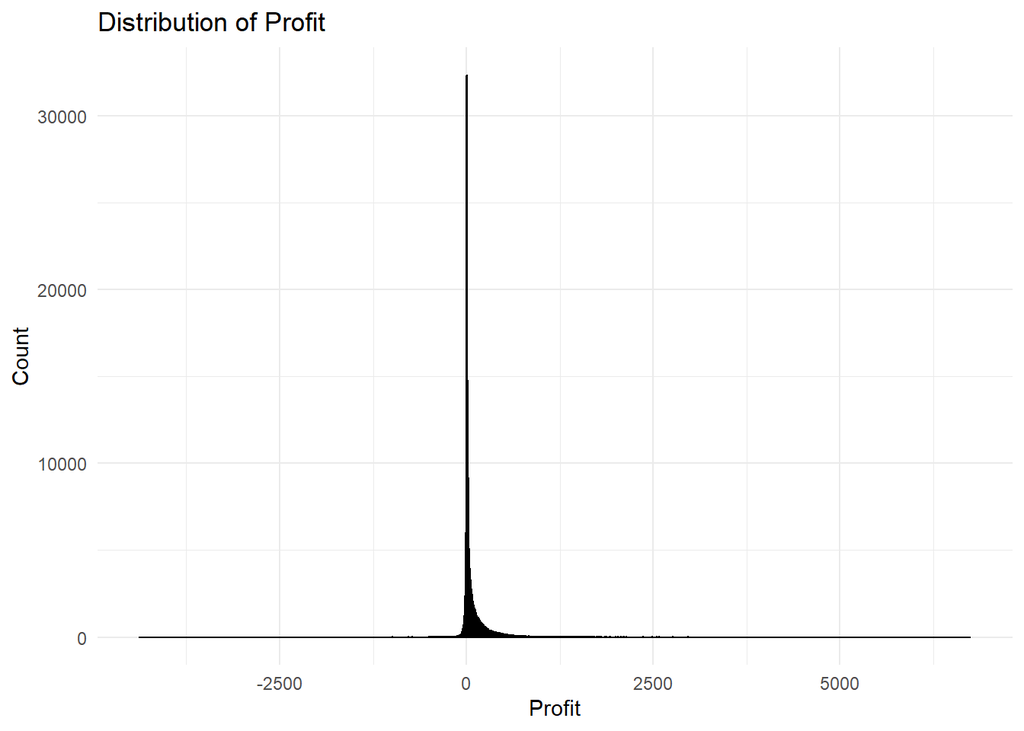

```r
# Create a histogram to see the spread of the 'profit' field
ggplot(bss_refresh, aes(x = profit)) +
  geom_histogram(binwidth = 10, fill = "blue", color = "black", alpha = 0.7) +
  theme_minimal() +
  labs(title = "Distribution of Profit", x = "Profit", y = "Count")
```

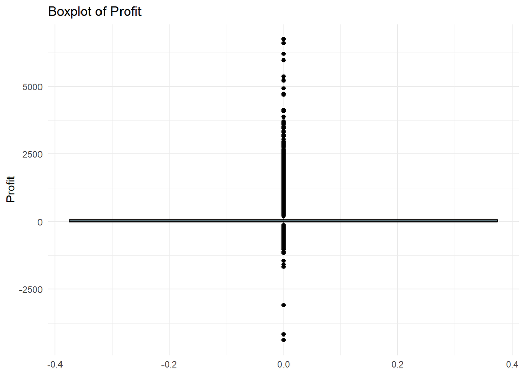

```r
# Create a boxplot to see the outliers in the 'profit' field
ggplot(bss_refresh, aes(y = profit)) +
  geom_boxplot(fill = "lightblue", color = "black") +
  theme_minimal() +
  labs(title = "Boxplot of Profit", y = "Profit")
```

Ok. These graphs weren’t very helpful. Maybe we’ll need to to check the distribution of the ‘comp_x_price’ variables.  
We’ll come back to it later.

Before we get into the **Time-Series Analysis**, let’s check whether the nature of the seasonality is additive or multiplicative.

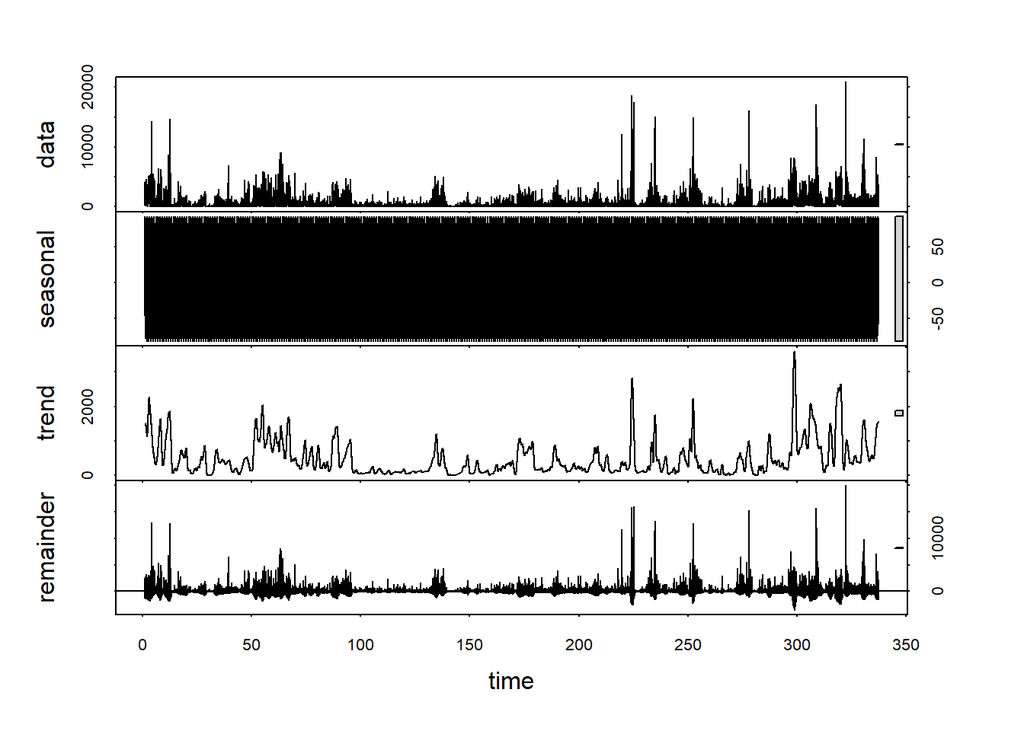

```r
bss_temp <- bss_refresh %>% select(salesdate,sales) # Create a temporary subset
bss_ts <- ts(bss_temp$sales,frequency = 365) # Capture the yearly seasonality

fit <- stl(bss_ts,s.window = "period")
plot(fit)
```

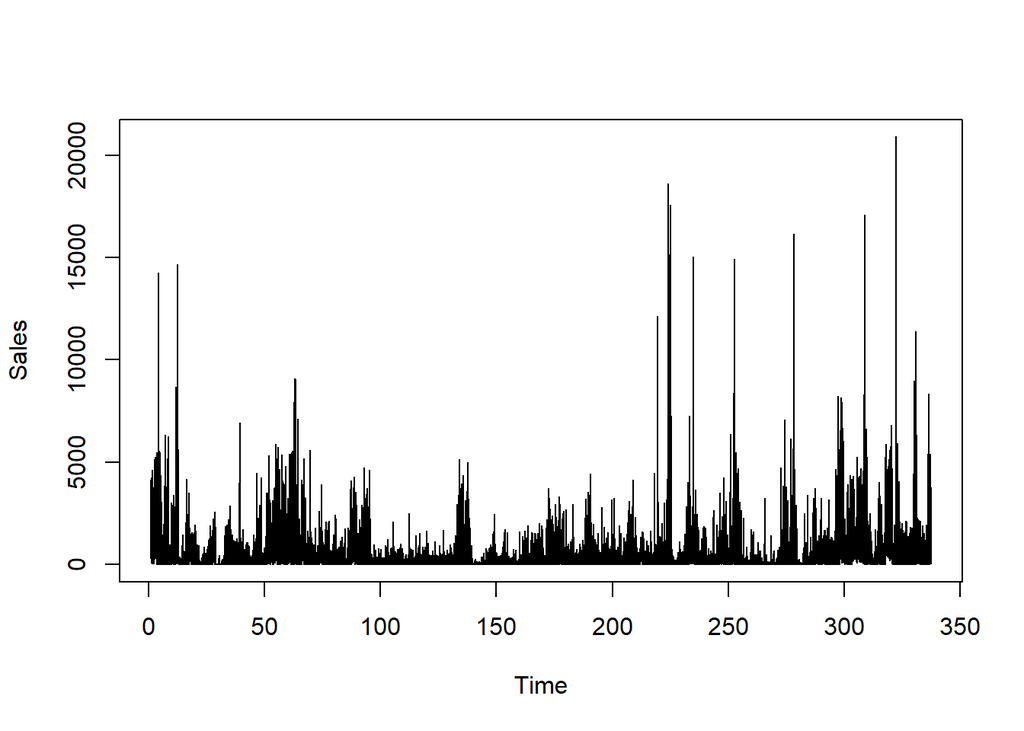

```r
additive_fit <- decompose(bss_ts,type = "additive")
multiplicative_fit <- decompose(bss_ts,type = "multiplicative")
plot(bss_ts,ylab = "Sales")
```

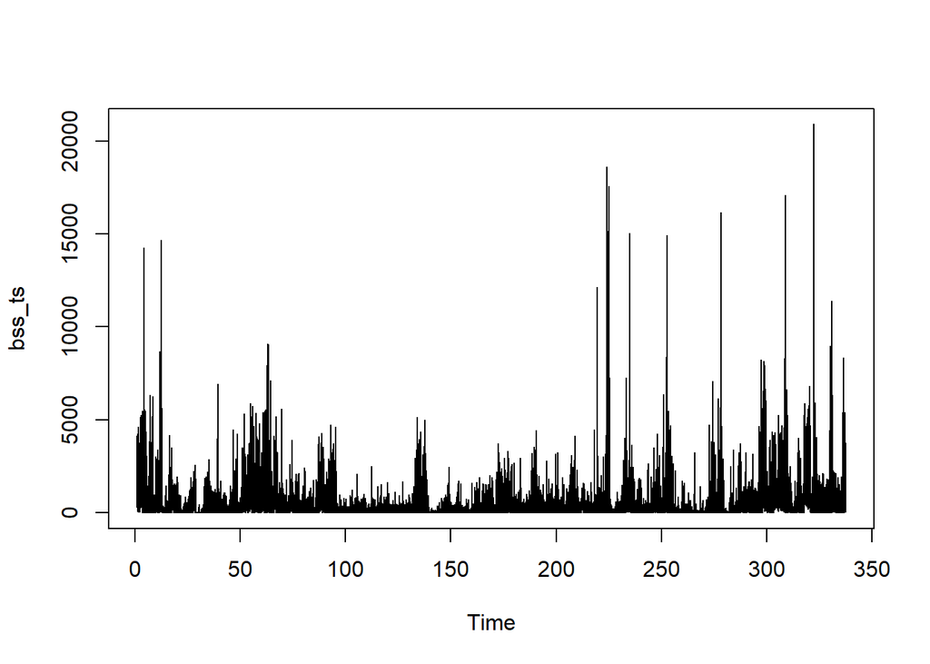

```r
# Do a basic time-series EDA of the sales over the entire period

# Visualize the inherent seasonality
plot(bss_ts)
plot.ts(bss_ts)
```

```r
# Check stationarity
adf.test(diff(bss_ts))
```

```
##
##  Augmented Dickey-Fuller Test
##
## data:  diff(bss_ts)
## Dickey-Fuller = -61.315, Lag order = 49, p-value = 0.01
## alternative hypothesis: stationary
```

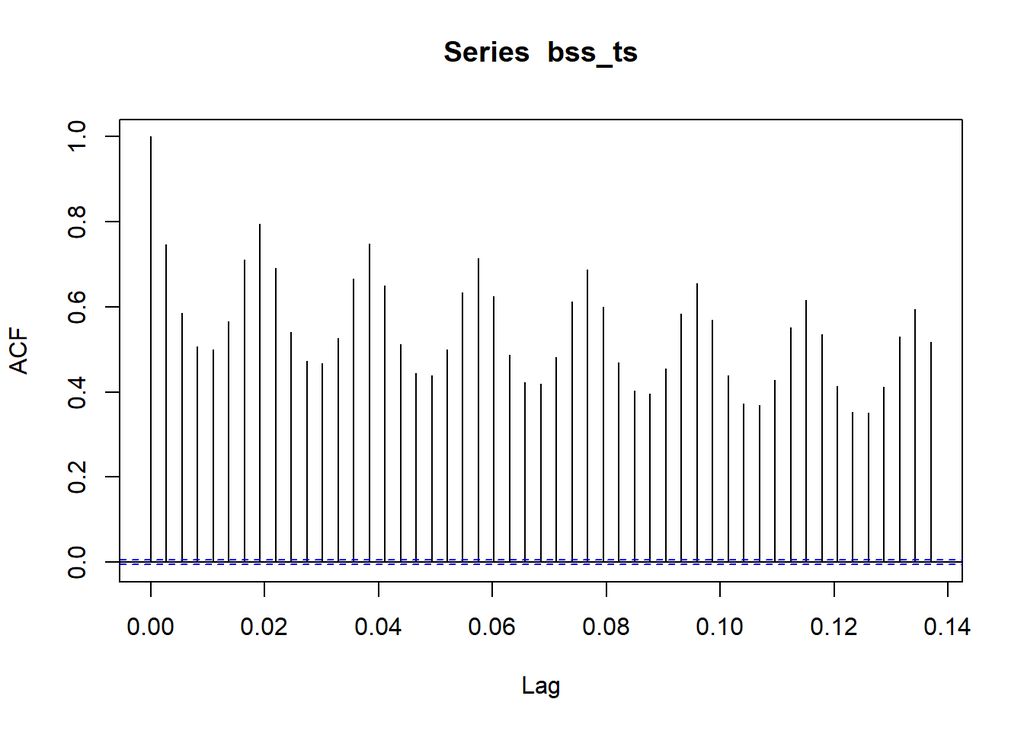

```r
acf(bss_ts)
```

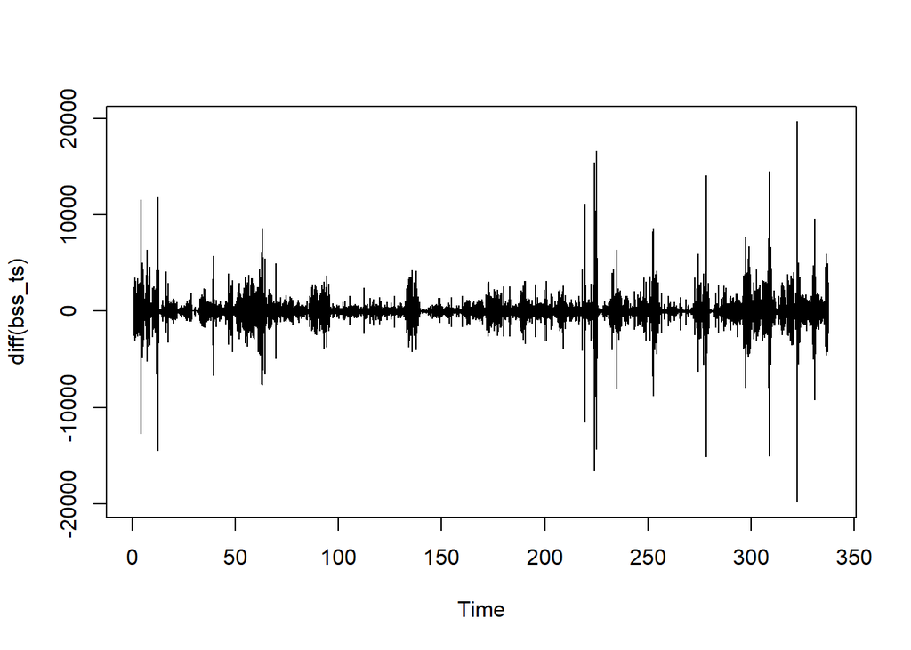

```r
# diff(bss_ts)
plot(diff(bss_ts)) # Plot the data after rendering it stationary
```

```r
# Create a function to aid the imputation in multiple columns
median_impute <- function(column) {
if (is.numeric(column)) {
return(ifelse(is.na(column), median(column, na.rm = TRUE), column))
} else {
return(column)  # return as-is for non-numeric columns
}
}

# A vector of column names that need to be imputed
cols_to_impute <- c("comp_1_price", "comp_2_price", "comp_3_price", "comp_4_price", "comp_5_price", "comp_data_min_price","comp_data_max_price","managed_fba_stock_level")

# Use vapply() to execute the created function on the requisite columns
bss_refresh[cols_to_impute] <- vapply(bss_refresh[cols_to_impute],median_impute, FUN.VALUE = numeric(nrow(bss_refresh)))

# Check to see the successful implementation
blank_count <- bss_refresh %>% summarize_all(funs(sum(is.na(.))))
print(blank_count)
```

```
##   sku salesdate price unitsordered sales cogs fba reffee adspend profit
## 1   0         0     0            0     0    0   0      0       0      0
##   comp_1_price comp_2_price comp_3_price comp_4_price comp_5_price
## 1            0            0            0            0            0
##   comp_data_min_price comp_data_max_price managed_fba_stock_level min_price
## 1                   0                   0                       0         0
##   max_price
## 1         0
```

```r
na_count_train <- bss_train %>% summarize_all(funs(sum(is.na(.)))) # Check the NA's in each field
na_count_train
```

```
##   sku salesdate price unitsordered sales cogs fba reffee adspend profit
## 1   0         0     0            0     0    0   0      0       0      0
##   comp_1_price comp_2_price comp_3_price comp_4_price comp_5_price
## 1        44069        74336       102042       115540       121025
##   comp_data_min_price comp_data_max_price managed_fba_stock_level min_price
## 1               37543               37543                   24202         0
##   max_price
## 1         0
```

```r
interpolate_impute <- function(col_name){
if(is.numeric(col_name)){
return(ifelse(is.na(col_name), na.approx(col_name), col_name))
}
else{
return(col_name)
}
}

bss_train[cols_to_impute]<-vapply(bss_train[cols_to_impute],interpolate_impute,FUN.VALUE = numeric(nrow(bss_train)))

na_count_train <- bss_train %>% summarize_all(funs(sum(is.na(.)))) # Check the NA's in each field
print(na_count_train)
```

```
##   sku salesdate price unitsordered sales cogs fba reffee adspend profit
## 1   0         0     0            0     0    0   0      0       0      0
##   comp_1_price comp_2_price comp_3_price comp_4_price comp_5_price
## 1            0            0            0            0            0
##   comp_data_min_price comp_data_max_price managed_fba_stock_level min_price
## 1                   0                   0                       0         0
##   max_price
## 1         0
```